# Expectation Maximization Algorithm - with one example

Kevin Liu

8/30/2018

Expectation Maximization Algorithm is a very important algorithm for mixture distribution. Here I derive the general form/step for mixture distribution with 2 distributions.

# 1 General form of EM algorithm for mixture distribution with 2 parts.

For $\mathbf{x} = (x_1,\dots,x_n)$, where $x_i$ is known numeric variable , with $f_0$ and $f_1$ being probability density functions. We assume that
$$\begin{equation}
P(X_i = x_i) = \pi_0 f_0(x_i) + \pi_1 f_1(x_i)
\tag{1.1}
\end{equation}$$
Important relationship between $\pi_0$ and $\pi_1$
$$\begin{equation}
\pi_0 + \pi_1 = 1
\tag{1.2}
\end{equation}$$

Define $\boldsymbol{\theta}$ is a vector containing all parameters of $f_0(x_i)$ and $f_1(x_i)$.

Define $Z_i$ as group information, which is unknown. The complete mixture probability distribution function is

$$\begin{equation}
f(x_i,Z_i;\boldsymbol{\theta}) = \mathbf{I}(Z_i = 0 | \mathbf{X}, \boldsymbol{\theta})\pi_0 f_0(x_i) +
\mathbf{I}(Z_i = 1 | \mathbf{X}, \boldsymbol{\theta})\pi_1 f_1(x_i)
\tag{1.3}
\end{equation}$$

Complete likelihood function

$$\begin{equation}
L(\boldsymbol{\theta}; \mathbf{X},\mathbf{Z}) = \prod_{i=1}^{n} [\mathbf{I}(Z_i = 0 | \mathbf{X}, \boldsymbol{\theta})\pi_0 f_0(x_i) +
\mathbf{I}(Z_i = 1 | \mathbf{X}, \boldsymbol{\theta})\pi_1 f_1(x_i)]
\tag{1.4}
\end{equation}$$
Complete log-likelihood function
$$\begin{equation}
\begin{split}
\ell(\boldsymbol{\theta}; \mathbf{X},\mathbf{Z}) &=
\text{log}[\prod_{i=1}^{n} [\mathbf{I}(Z_i = 0 | \mathbf{X}, \boldsymbol{\theta})\pi_0 f_0(x_i) +
\mathbf{I}(Z_i = 1 | \mathbf{X}, \boldsymbol{\theta})\pi_1 f_1(x_i)]] \\
&= \sum_{i=1}^{n} \text{log}[\mathbf{I}(Z_i = 0 | \mathbf{X}, \boldsymbol{\theta})\pi_0 f_0(x_i) +
\mathbf{I}(Z_i = 1 | \mathbf{X}, \boldsymbol{\theta})\pi_1 f_1(x_i)] \\
&= \sum_{i=1}^{n} \mathbf{I}(Z_i = 0 | \mathbf{X}, \boldsymbol{\theta})\text{log}[\pi_0 f_0(x_i)] +
\mathbf{I}(Z_i = 1 | \mathbf{X}, \boldsymbol{\theta})\text{log}[\pi_1 f_1(x_i)]
\end{split}
\tag{1.5}
\end{equation}$$

The last step of (1.5) is true because $Z_i$ could be either $0$ or $1$, but $Z_i$ can not be $0$ and $1$ simultaneous.

The E step:

The M step is relatively easy. It is about finding the parameters that maximize this quantity.

$$\begin{equation}
\begin{split}
\boldsymbol{\theta}^{(t+1)} = \text{argmax} Q(\boldsymbol{\theta} | \boldsymbol{\theta}^{(t)})
\end{split}
\tag{1.7}
\end{equation}$$

# 2 Example

This example comes from Prof.Zhao who works in Temple University and introduced me the EM algorithm. He made an good homework for EM. I decide to share the homework.

Assume

$$\begin{equation}
\begin{cases}
f_0(x_i) = 1(0 \le x_i \le 1)\\
f_1(x_i)=\beta(1-x_i)^{\beta-1}
\end{cases}
\tag{2.1}
\end{equation}$$

$$\begin{equation}
\begin{split}
Q(\boldsymbol{\theta} | \boldsymbol{\theta}^{(t)}) &=
\sum_{i=1}^{n}
T^{(t)}_{0,i}
\text{log}(\pi_0 \times 1)
+
T^{(t)}_{1,i}
\text{log}(\pi_1 \times \beta(1-x_i)^{\beta-1})\\
&\stackrel{(1.2)}{=}
\sum_{i=1}^{n}
T^{(t)}_{0,i}
\text{log}(\pi_0 \times 1)
+
T^{(t)}_{1,i}
\text{log}((1-\pi_0) \times \beta(1-x_i)^{\beta-1})
\end{split}
\tag{2.2}
\end{equation}$$

From calculus, we know that first derivatives must be 0. (Note: $T^{(t)}_{j,i}$, which is defined in appendix A.4, should be treated as constant)

$$\begin{equation}
\frac{\partial Q(\boldsymbol{\theta} | \boldsymbol{\theta}^{(t)})}{\partial \pi_0} =
\sum_{i=1}^{n}
T^{(t)}_{0,i}
\frac{1}{\pi_0}
+
\sum_{i=1}^{n}
T^{(t)}_{1,i}
\frac{1}{\pi_0 - 1} = 0
\tag{2.3}
\end{equation}$$

This implies

$$\begin{equation}
\pi_0^{(t+1)} = \frac{\sum_{i=1}^{n}
T^{(t)}_{0,i}}{\sum_{i=1}^{n}
T^{(t)}_{0,i} + \sum_{i=1}^{n}
T^{(t)}_{1,i}}
=
\frac{\sum_{i=1}^{n}
T^{(t)}_{0,i}}{\sum_{i=1}^{n} (
T^{(t)}_{0,i} + T^{(t)}_{1,i})}
= \frac{\sum_{i=1}^{n}
T^{(t)}_{0,i}}{n}
\tag{2.4}
\end{equation}$$

Similarly, we have that

$$\begin{equation}
\frac{\partial Q(\boldsymbol{\theta} | \boldsymbol{\theta}^{(t)})}{\partial \beta} =
\sum_{i=1}^{n}
T^{(t)}_{1,i}
(\frac{1}{\beta} + log(1-x_i)) = 0
\tag{2.5}
\end{equation}$$

This implies

$$\begin{equation}
\beta^{(t+1)} = \frac{\sum_{i=1}^{n}
T^{(t)}_{1,i}}{-\sum_{i=1}^{n}
T^{(t)}_{1,i} log(1-x_i)}
\tag{2.6}
\end{equation}$$

## 2.1 Example - Calculation by `R`

Create a loop in `R` to get $\pi_0$ and $\beta$. With initial value of $0.69$ and $11$, at 32th iteration, $\pi_0 = 0.69679$ and $\beta = 11.09328$. (Initial value are chosen on purpose so it doesn’t require too many iterations until converge).

Link:pvalue.csv. Note that `pvalue.csv` is simulated data.

```r
pvalue <- read.csv("files/pvalue.csv")

em <- function(X,s) {
  T0.all <- s[1]/ (s[1]+(1-s[1])*s[2]*(1-X)^(s[2]-1))
  s[1] <- mean(T0.all)
  s[2] <- -sum(1-T0.all)/sum((1-T0.all)*(log(1-X)))
  return(s)
}

s.old <- c(0.69, 11)
s.new <- s.old
delta <- 0.0001
Delta <- 1
ITR <- 1
while( Delta > delta ){
  s.new <- em(X = pvalue$X, s.old)
  Delta <- sum( (s.new-s.old)^2 )
  Delta <- max( abs(s.new-s.old) )
  ITR <- ITR+1
  s.old <- s.new
  print( paste(ITR, "-th iteration: pi0=", s.new[1], ", beta=", s.new[2] ) )
}
```

```
## [1] "2 -th iteration: pi0= 0.692953136521137 , beta= 10.9669224885903"
## [1] "3 -th iteration: pi0= 0.694245784180573 , beta= 10.9727031763405"
## [1] "4 -th iteration: pi0= 0.69491869223006 , beta= 10.988768636732"
## [1] "5 -th iteration: pi0= 0.695335476190631 , beta= 11.0058596812566"
## [1] "6 -th iteration: pi0= 0.695629559921737 , beta= 11.0212140150885"
## [1] "7 -th iteration: pi0= 0.695853527007361 , beta= 11.0342459020068"
## [1] "8 -th iteration: pi0= 0.696030723377971 , beta= 11.0450623202825"
## [1] "9 -th iteration: pi0= 0.696173386989525 , beta= 11.0539564879985"
## [1] "10 -th iteration: pi0= 0.696289132284208 , beta= 11.0612405367788"
## [1] "11 -th iteration: pi0= 0.69638334812323 , beta= 11.0671951901675"
## [1] "12 -th iteration: pi0= 0.696460145936134 , beta= 11.0720589742552"
## [1] "13 -th iteration: pi0= 0.696522781969357 , beta= 11.0760300668865"
## [1] "14 -th iteration: pi0= 0.696573879508717 , beta= 11.0792715728663"
## [1] "15 -th iteration: pi0= 0.69661556770814 , beta= 11.0819171723944"
## [1] "16 -th iteration: pi0= 0.696649580151097 , beta= 11.0840762181639"
```

[output cut: 16 more lines]

## 2.2 Example - Histogram

```r
library(ggplot2)
pi0 <- s.new[1]
pi1 <- 1-pi0
beta <- s.new[2]
hist.plot <- hist(pvalue$X, br=40, plot = FALSE)
df.plot <- data.frame(x = hist.plot$breaks[-1], y = hist.plot$density)
list.density <- density(pvalue$X)
df.plot2 <- data.frame(x = list.density$x, y = list.density$y)
df.plot2 <- subset(df.plot2, x >=0 & x <=1)
df.plot2["color"] <- "Gaussian Kernel Density Estimation"

df.plot3 <- data.frame(x = df.plot2$x)
df.plot3["y"] <- (pi0*1+ pi1*beta*(1-df.plot3$x)^(beta-1))
df.plot3["color"] <- "EM Estimation"

df.line <- rbind(df.plot2,df.plot3)
rm(df.plot2,df.plot3)

ggplot(data = df.plot, aes(x = x, y = y)) +
  geom_col(fill = "#B9CFE7", colour = "black") +
  geom_line(data = df.line ,aes(x = x, y = y, color = color),size = 1) +
  scale_y_continuous("density") +
  theme_bw() +
  scale_color_manual(values = c("#F0E442","#FF9999"), name = element_blank()) +
  theme(legend.position = "bottom")
```

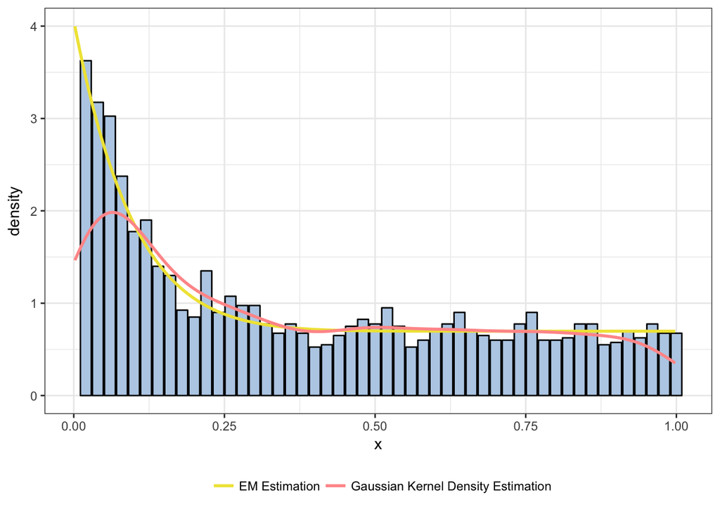

[figure not shown]

From the histogram, we can easily see that EM density estimation fits the real density very well. Not surprise to us, EM density estimation is a better choice comparing with Gaussian kernel density estimation for this data set.

## 2.3 Example - EM algorithm as a classification tool for mixture probabaility density.

We can classify $x_i$ to be 1st group if $T_{0,i}=P(z_i=0|\mathbf{x};\boldsymbol{\theta}^{(\text{32th iteration})}) \stackrel{(\text{A.}4)}{=} \frac{0.69679 \times 1}{0.69679 \times 1 + (1-0.69679) \times 11.09327(1-x_i)^{(11.09327 -1)}} > 0.5$.

Use `R` to calculate

```r
pvalue["p0"] <- s.new[1]/(s.new[1] + (1-s.new[1]) * s.new[2] * (1-pvalue$X)^(s.new[2] - 1))
pvalue[pvalue$p0 >= 0.5, "estimated_group"] <- as.integer(0)
pvalue[pvalue$p0 < 0.5, "estimated_group"] <- as.integer(1)
pvalue[pvalue$group == pvalue$estimated_group,"Diff"] <- "Right classified"
pvalue[pvalue$group != pvalue$estimated_group,"Diff"] <- "False classified"
table(pvalue$Diff)
```

```
##
## False classified Right classified
##              321             1679
```

The total number of false classified is $321$. The false classified rate is $321/(321+1679) = 0.1605$.

# 3 Appendix

For $X$ and $Y$ are random variables,
$$\begin{equation}
E[X+Y] = E[X] + E[Y]
\tag{A.1}
\end{equation}$$
For $X$ is a random variable and $a$ is a scalar,
$$\begin{equation}
E[aX] = aE[X]
\tag{A.2}
\end{equation}$$

For $A$ is an event, $\mathbf{I}_A$ is [indicator function](https://en.wikipedia.org/wiki/Indicator_function) of the set $A$,

$$\begin{equation}
E[\mathbf{I}_A] = P(A)
\tag{A.3}
\end{equation}$$

For $Z_i$ is group information, which is unknown and $X_i$ is known data and both $Z_i$ and $X_i$ are considered as random variables.

$$\begin{equation}
\begin{cases}
T_{i,0} = P(Z_i = 0 | X_i = x_i; \tilde{\boldsymbol{\theta}}) =
\frac{P(Z_i = 0 \cap X_i = x_i; \tilde{\boldsymbol{\theta}})}
{ P(X_i = x_i; \tilde{\boldsymbol{\theta}})}
= \frac{\pi_0 f_0(x_i)}{\pi_0 f_0(x_i) + \pi_1 f_1(x_i)} \\
T_{i,1} = P(Z_i = 1 | X_i = x_i; \tilde{\boldsymbol{\theta}}) =
\frac{P(Z_i = 1 \cap X_i = x_i; \tilde{\boldsymbol{\theta}})}
{ P(X_i = x_i; \tilde{\boldsymbol{\theta}})}
= \frac{\pi_1 f_1(x_i)}{\pi_0 f_0(x_i) + \pi_1 f_1(x_i)}
\end{cases}
\tag{A.4}
\end{equation}$$